# EXAME_PARTE_II-MOQ-13

Bruno Lima Queiroz Santos

30/11/2019

### Questão 1

Um teste adequado a ser realizado é o teste t-student para as variações amostrais. Hipótese Nula: $H_{0}: \mu=4$ , Hipótese alternativa: $H_{a}<4$. Sendo a amostra de $n=20$ elementos, com uma variância de $s^{2}=5.62 \Leftrightarrow s=\sqrt{5.62}$ .

$$t_{n-1} \sim \frac{\overline{x}-\mu}{s/\sqrt{n}} \equiv \frac{\Delta x}{s/\sqrt{n}}$$
$$\Leftrightarrow P(\Delta x \geq 4)= P\Bigg[t_{n-1}\geq\frac{4\sqrt{n}}{s}\Bigg]=P\Bigg[t_{n-1}\geq7.54583\Bigg]$$

```r
n<-20
x<-4
x<-x*sqrt(20)
x<-x/sqrt(5.62)
cat("A probabilidade P(t_n-1>7.54583) = ", round(pt(x,n-1,lower.tail=FALSE),8))
```

```
## A probabilidade P(t_n-1>7.54583) =  2e-07
```

Criando uma amostra e testando-a.

```r
X<-rnorm(n,mean=0,sd=sqrt(5.62))
Y<-X
Y<-Y-mean(Y)
Y<-Y/sd(Y)
Y<-Y*sqrt(length(Y))
t.test(Y,alternative="less",mu=4,conf.level=0.90)
```

```
##
##  One Sample t-test
##
## data:  Y
## t = -4, df = 19, p-value = 0.0003831
## alternative hypothesis: true mean is less than 4
## 90 percent confidence interval:
##      -Inf 1.327728
## sample estimates:
##     mean of x
## -6.375109e-18
```

De acordo com o teste realizado, a hipótese nula é descartada por um t-test de significância $\alpha=0.10$ aplicado sobre uma amostra de distribuição normal com $\mu=0$,$\sigma^{2}=5.62$

O poder do teste é $P($ rejeitar $H_{0} | H_{a}$ verdadeira$)$. Assumindo que $H_{a}$ é verdadeira, a probabilidade é justamente $P(\Delta x < 4)=P\Bigg[t_{n-1}<\frac{4\sqrt{n}}{s} \equiv q\Bigg]$

```r
quantil<-function(N,S,Mu){
  q<-Mu
  q<-q*sqrt(N)
  s<-sqrt(S) # STANDARD_DEVIATION by variance
  q<-q/s
  return(q)
}
q<-quantil(n,5.62, 4.0)
Power<-pt(q,n-1)
cat("O poder do teste é = ", Power)
```

```
## O poder do teste é =  0.9999998
```

O poder do teste é $99.99998\%$

Para $\sigma_{A}^{2}=7$:

```r
q<-quantil(n,7.0, 4.0)
Power<-pt(q,n-1)
cat("O poder do teste é = ", Power)
```

```
## O poder do teste é =  0.9999991
```

O poder do teste é $99.99991\%$

$n \propto q^{2} \;\; | \;\;P\Bigg[ t < q\Bigg]=0.90$.

```r
s<-sqrt(7.0)
n<-10
F_quantile<-function(n,s){
  Q<-(4.0*sqrt(n))/s
  return (p<-pt(Q,n-1))
}
p<-100
while(p>0.90 & n>1){
  p<-F_quantile(n,sqrt(7.0))
  n<-n-1
}
cat("n = ", n+1, "p = ", p)
```

```
## n =  2 p =  0.8607454
```

```r
F_quantile(2,sqrt(7.0))
```

```
## [1] 0.8607454
```

```r
F_quantile(3,sqrt(7.0))
```

```
## [1] 0.9399413
```

Portanto, é possível concluir que $n=3$ garante potência de $0.90$ com $\sigma^{2}_{A}=7$

### Questão 2

```r
A<-c(776.58,672.00,1251.60,1133.58,797.58,965.58,735.00,1173.90,1238.58,1362.90,949.20,1385.58,839.58,562.38)
B<-matrix(A,ncol=2)
B
```

```
##         [,1]    [,2]
## [1,]  776.58 1173.90
## [2,]  672.00 1238.58
## [3,] 1251.60 1362.90
## [4,] 1133.58  949.20
## [5,]  797.58 1385.58
## [6,]  965.58  839.58
## [7,]  735.00  562.38
```

```r
B<-B/4.20
A<-A/4.20
```

1. Preços em Dólar

```r
B
```

```
##       [,1]  [,2]
## [1,] 184.9 279.5
## [2,] 160.0 294.9
## [3,] 298.0 324.5
## [4,] 269.9 226.0
## [5,] 189.9 329.9
## [6,] 229.9 199.9
## [7,] 175.0 133.9
```

Média

```r
mean(A)
```

```
## [1] 235.4429
```

Desvio Padrão

```r
sd(A)
```

```
## [1] 63.90981
```

boxplot

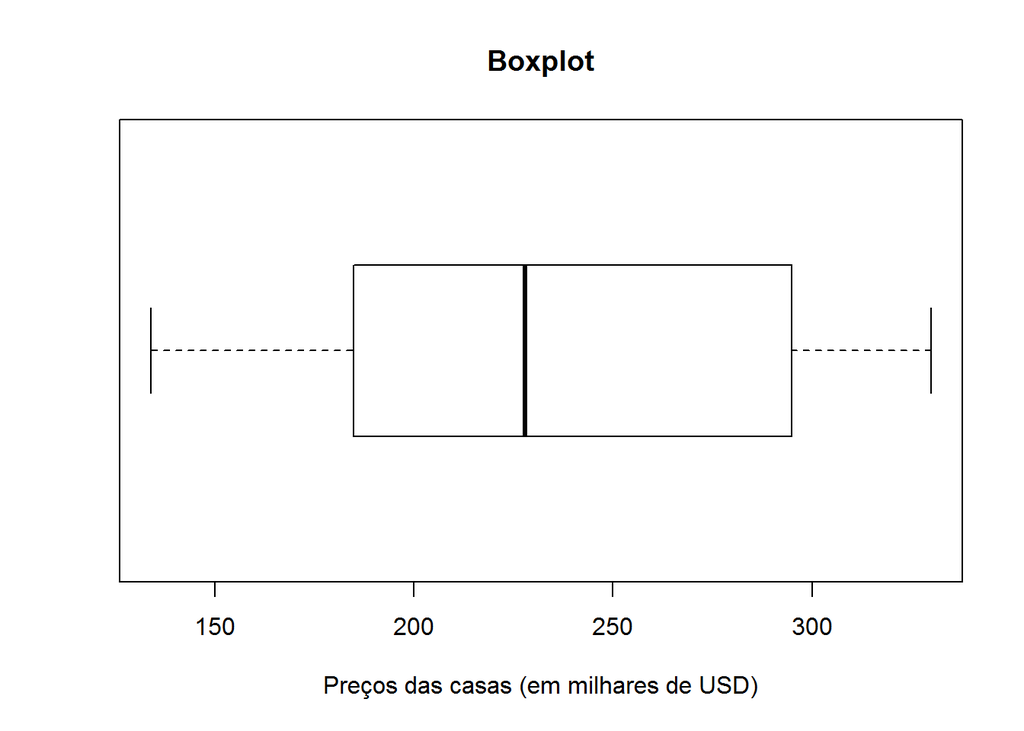

```r
boxplot(
        A,
        xlab = "Preços das casas (em milhares de USD)",
        horizontal=TRUE,
        main = "Boxplot"
    )
```

QQPlot

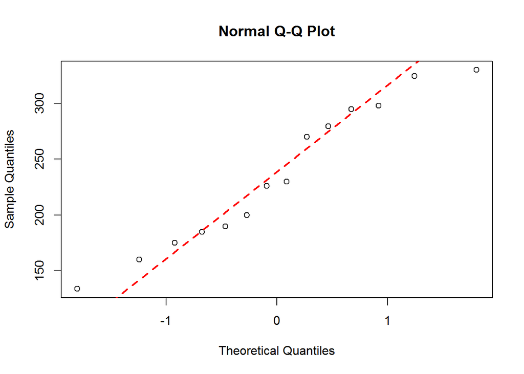

```r
##qqnorm(A,xaxt="n",yaxt="n",xlab="",ylab="",main="Q-Q")
qqnorm(A)
qqline(A,col=2,lwd=2,lty=2)
```

É evidenciada uma distribuição simétrica em torno da média, ou de um valor razoavelmente próximo da média, levantando suspeitas sobre ser uma distribuição normal.

3. Testes de normalidade

### Teste de Kolmogorov-Smirnov [ks.test]

```r
y<-rnorm(length(A))
ks.test(A,y)
```

```
##
##  Two-sample Kolmogorov-Smirnov test
##
## data:  A and y
## D = 1, p-value = 4.985e-08
## alternative hypothesis: two-sided
```

```r
y<-rnorm(length(A),sd=sd(A))
ks.test(A,y)
```

```
##
##  Two-sample Kolmogorov-Smirnov test
##
## data:  A and y
## D = 1, p-value = 4.985e-08
## alternative hypothesis: two-sided
```

```r
y<-rnorm(length(A),mean=mean(A))
ks.test(A,y)
```

```
##
##  Two-sample Kolmogorov-Smirnov test
##
## data:  A and y
## D = 0.57143, p-value = 0.01878
## alternative hypothesis: two-sided
```

```r
y<-rnorm(length(A),mean=mean(A),sd=sd(A))
ks.test(A,y)
```

```
##
##  Two-sample Kolmogorov-Smirnov test
##
## data:  A and y
## D = 0.14286, p-value = 0.9996
## alternative hypothesis: two-sided
```

### Teste de Shapiro-Wilk [shapiro.test]

```r
shapiro.test(A)
```

```
##
##  Shapiro-Wilk normality test
##
## data:  A
## W = 0.94397, p-value = 0.4715
```

### Teste de Anderson-Darlin [ad.test]

```r
library(nortest)
ad.test(A)
```

```
##
##  Anderson-Darling normality test
##
## data:  A
## A = 0.3219, p-value = 0.4909
```

### Lilliefors [lillie.test]

```r
lillie.test(A)
```

```
##
##  Lilliefors (Kolmogorov-Smirnov) normality test
##
## data:  A
## D = 0.13951, p-value = 0.6495
```

Conclusão:

Todos os testes apresentam p-valor maior que $5.0 \%$, inclusive o teste de Kolmogorov-Smirnov, em uma análise mais atenta, observando-se que há compatibilidade entre uma amostra normal cujos parâmetros populacionais têm valores próximos dos parâmetros estimados a partir da amostra analisada, embora o teste rejeite a hipótese nula quando não se fornecem os parâmetros populacionais compatíveis com o da amostra, isto é, os parâmetros padrão $\mu=0, \sigma=1$ não são compatíveis com os da amostra. Ou seja, há evidências de que a amostra segue uma distribuição normal não padronizada, pois a hipótese nula de que a função de distribuição é igual a uma função de distribuição normal não pode ser descartada com significância de 0.05 por qualquer um dos testes.

4. $$t_{n-1} \sim \frac{\overline{x}-\mu}{s/\sqrt{n}}$$
   $$P\Bigg[ t_{(\alpha/2,n-1)} \leq\frac{\overline{x}-\mu}{s/\sqrt{n}}\leq t_{(1-\alpha/2,n-1)} \Bigg]=\alpha$$

$$\Leftrightarrow P\Bigg[ (s/\sqrt{n})t_{(\alpha/2,n-1)} \leq\overline{x}-\mu\leq t_{(1-\alpha/2,n-1)}(s/\sqrt{n}) \Bigg]=\alpha$$

$$\Leftrightarrow P\Bigg[ (-)t_{(1-\alpha/2,n-1)}(s/\sqrt{n}) \leq\mu-\overline{x}\leq(s/\sqrt{n})(-)t_{(\alpha/2,n-1)}\Bigg]=\alpha$$

usando-se que :

$$0=t_{(1-\alpha/2,n-1)}+t_{(\alpha/2,n-1)} \Leftrightarrow -t_{(\alpha/2,n-1)} = + t_{(1-\alpha/2,n-1)}$$

$$\Rightarrow P\Bigg[ \overline{x}-t_{(1-\alpha/2,n-1)}(s/\sqrt{n}) \leq\mu\leq\overline{x}+t_{(1-\alpha/2,n-1)}(s/\sqrt{n})\Bigg]=\alpha$$

Logo, $\alpha=0.05 \Leftrightarrow \frac{\alpha}{2}=0.025$ e $n=14$ :
$$\overline{x}-t_{(0.975,13)}(s/\sqrt{14}) \leq\mu\leq\overline{x}+t_{(0.975,13)}(s/\sqrt{14})$$
Com : $\overline{x}=\sum \frac{x_{i}}{n}$,$s=\sqrt{\frac{(x_{i}-\overline{x})^{2}}{n-1}}$

```r
x<-sum(A)
n<-length(A)
x<-x/n
s<-(A-x)^2
s<-sum(s)
s<-s/(n-1)
s<-sqrt(s)

x_inf<-x-qt(0.975,13)*(s/sqrt(14))
x_sup<-x+qt(0.975,13)*(s/sqrt(14))
cat("95% por cento IC:", x_inf,"  ",x_sup)
```

```
## 95% por cento IC: 198.5424    272.3433
```

```r
t.test(A)
```

```
##
##  One Sample t-test
##
## data:  A
## t = 13.784, df = 13, p-value = 3.898e-09
## alternative hypothesis: true mean is not equal to 0
## 95 percent confidence interval:
##  198.5424 272.3433
## sample estimates:
## mean of x
##  235.4429
```

De onde obtêm-se os mesmos resultados para o intervalo de confidência $95\%$.

```r
t.test(A,conf.level=0.95)
```

```
##
##  One Sample t-test
##
## data:  A
## t = 13.784, df = 13, p-value = 3.898e-09
## alternative hypothesis: true mean is not equal to 0
## 95 percent confidence interval:
##  198.5424 272.3433
## sample estimates:
## mean of x
##  235.4429
```

De acordo com o intervalo de confidência de $95\%$, há evidências com significância de $0.05$ de que a alegação do corretor é falsa, pois a média alegada está fora do Intervalo de Confidência de $95\%$. Ou seja, a estimativa é de que a cada 100 amostras, apenas 5 contenham a média de preço fora do intervalo de confidência, ao contrário das demais 95.